# Methylation analysis test with MethylKit

Hernan Lorenzi

```r
library(genomation)
```

```r
file.list.zKO <-list(
                  "./data/GSE116489_RAW/GSM3240131_CpG_3L_4_methylKit.txt.gz",
                  "./data/GSE116489_RAW/GSM3240132_CpG_3L_5_methylKit.txt.gz",
                  "./data/GSE116489_RAW/GSM3240133_CpG_3L_6_methylKit.txt.gz",
                  "./data/GSE116489_RAW/GSM3240134_CpG_3L_7_methylKit.txt.gz",
                  "./data/GSE116489_RAW/GSM3240135_CpG_3L_9_methylKit.txt.gz")

# read the files to a methylRawList object: myobj
myobj <- methRead(location = file.list.zKO,
           sample.id=list("WT_1",   "WT_2",   "WT_3",   "zKO_1",  "zKO_2"),
           assembly="mm10",
           treatment=c(0,0,0,1,1),
           context="CpG",
           mincov = 20
           )
```

```
Received list of locations.
Uncompressing file.
Reading file.
Uncompressing file.
Reading file.
Uncompressing file.
Reading file.
Uncompressing file.
Reading file.
Uncompressing file.
Reading file.
```

```r
# read the gene BED file
gene.obj <- readTranscriptFeatures(location = "./data/UCSC_GENCODEvm23.tsv", up.flank = 1000, down.flank = 500, unique.prom = TRUE)
```

```
Reading the table...
Calculating intron coordinates...
Calculating exon coordinates...
Calculating TSS coordinates...
Calculating promoter coordinates...
Outputting the final GRangesList...
```

```r
cpg.obj <- readFeatureFlank(location = "./data/UCSC_CpG_islands.tsv", remove.unusual = TRUE,
  flank = 0, clean = TRUE, feature.flank.name = NULL)
```

```r
getMethylationStats(myobj[[2]],plot=FALSE,both.strands=FALSE)
```

```
methylation statistics per base
summary:
   Min. 1st Qu.  Median    Mean 3rd Qu.    Max.
  0.000   0.000   2.778  24.928  45.614 100.000
percentiles:
        0%        10%        20%        30%        40%        50%        60%        70%
  0.000000   0.000000   0.000000   0.000000   1.123596   2.777778   6.611570  14.492754
       80%        90%        95%        99%      99.5%      99.9%       100%
 82.716049  93.333333  96.153846 100.000000 100.000000 100.000000 100.000000
```

```r
dir.create(path = "./Plots", showWarnings = FALSE)
pdf(file = "./Plots/perc_meth_hist.pdf")
for (i in 1:length(myobj)){
  getMethylationStats(myobj[[i]],plot=TRUE,both.strands=FALSE)
}
dev.off()
```

We can also plot the read coverage per base information in a similar way, again numbers on bars denote what percentage of locations are contained in that bin. Experiments that are highly suffering from PCR duplication bias will have a secondary peak towards the right hand side of the histogram.

```r
pdf(file = "./Plots/read_cov_hist.pdf")
for (i in 1:length(myobj)){
  getCoverageStats(myobj[[i]],plot=TRUE,both.strands=FALSE)
}
dev.off()
```

```r
filtered.myobj=filterByCoverage(myobj,lo.count=20,lo.perc=NULL,
                                      hi.count=NULL,hi.perc=99.9)
```

In order to do further analysis, we will need to get the bases covered in all samples. The following function will merge all samples to one object for base-pair locations that are covered in all samples. Setting destrand=TRUE (the default is FALSE) will merge reads on both strands of a CpG dinucleotide. This provides better coverage, but only advised when looking at CpG methylation (for CpH methylation this will cause wrong results in subsequent analyses). In addition, setting destrand=TRUE will only work when operating on base-pair resolution, otherwise setting this option TRUE will have no effect. The unite() function will return a methylBase object which will be our main object for all comparative analysis. The methylBase object contains methylation information for regions/bases that are covered in all samples.

```r
#meth=unite(filtered.myobj, destrand=TRUE, min.per.group = 2L, mc.cores = 16)
meth=unite(filtered.myobj, destrand=TRUE, mc.cores = 16)
```

```
destranding...
uniting...
```

```r
meth
```

```
methylBase object with 481936 rows
--------------
```

|  | chr | start | end | strand | coverage1 | numCs1 | numTs1 | coverage2 | numCs2 | numTs2 | coverage3 | numCs3 | numTs3 | coverage4 | numCs4 | numTs4 | coverage5 | numCs5 | numTs5 |
| --- | --- | --- | --- | --- | --- | --- | --- | --- | --- | --- | --- | --- | --- | --- | --- | --- | --- | --- | --- |
| 1 | chr1 | 3020877 | 3020877 | + | 138 | 135 | 3 | 86 | 77 | 9 | 135 | 126 | 9 | 137 | 129 | 8 | 98 | 93 | 5 |
| 2 | chr1 | 3020891 | 3020891 | + | 143 | 135 | 8 | 88 | 80 | 8 | 135 | 125 | 10 | 139 | 129 | 10 | 100 | 95 | 5 |
| 3 | chr1 | 3020945 | 3020945 | + | 185 | 160 | 25 | 112 | 92 | 20 | 124 | 102 | 22 | 127 | 98 | 29 | 121 | 100 | 21 |
| 4 | chr1 | 3020987 | 3020987 | + | 185 | 173 | 12 | 111 | 106 | 5 | 130 | 126 | 4 | 153 | 133 | 20 | 122 | 102 | 20 |
| 5 | chr1 | 3021012 | 3021012 | + | 183 | 172 | 11 | 110 | 108 | 2 | 127 | 121 | 6 | 149 | 140 | 9 | 121 | 111 | 10 |
| 6 | chr1 | 3622256 | 3622256 | + | 264 | 248 | 16 | 169 | 157 | 12 | 157 | 144 | 13 | 234 | 220 | 14 | 217 | 195 | 22 |

```
--------------
sample.ids: WT_1 WT_2 WT_3 zKO_1 zKO_2
destranded TRUE
assembly: mm10
context: CpG
treament: 0 0 0 1 1
resolution: base
```

We can check the correlation between samples using getCorrelation. This function will either plot scatter plot and correlation coefficients or just print a correlation matrix.

```r
pdf("./Plots/sample_correlations.pdf")
  getCorrelation(meth,plot=FALSE)
```

```
           WT_1      WT_2      WT_3     zKO_1     zKO_2
WT_1  1.0000000 0.9932832 0.9934755 0.9863541 0.9879271
WT_2  0.9932832 1.0000000 0.9934450 0.9873855 0.9885564
WT_3  0.9934755 0.9934450 1.0000000 0.9860546 0.9875907
zKO_1 0.9863541 0.9873855 0.9860546 1.0000000 0.9927377
zKO_2 0.9879271 0.9885564 0.9875907 0.9927377 1.0000000
```

```r
dev.off()
```

We can cluster the samples based on the similarity of their methylation profiles. The following function will cluster the samples and draw a dendrogram.

```r
pdf("./Plots/sample_clustering_correl.pdf")
  clusterSamples(meth, dist="correlation", method="ward", plot=TRUE)
```

```
The "ward" method has been renamed to "ward.D"; note new "ward.D2"
```

```
Call:
hclust(d = d, method = HCLUST.METHODS[hclust.method])

Cluster method   : ward.D
Distance         : pearson
Number of objects: 5
```

```r
dev.off()
```

```
The "ward" method has been renamed to "ward.D"; note new "ward.D2"
```

```
Call:
hclust(d = d, method = HCLUST.METHODS[hclust.method])

Cluster method   : ward.D
Distance         : pearson
Number of objects: 5
```

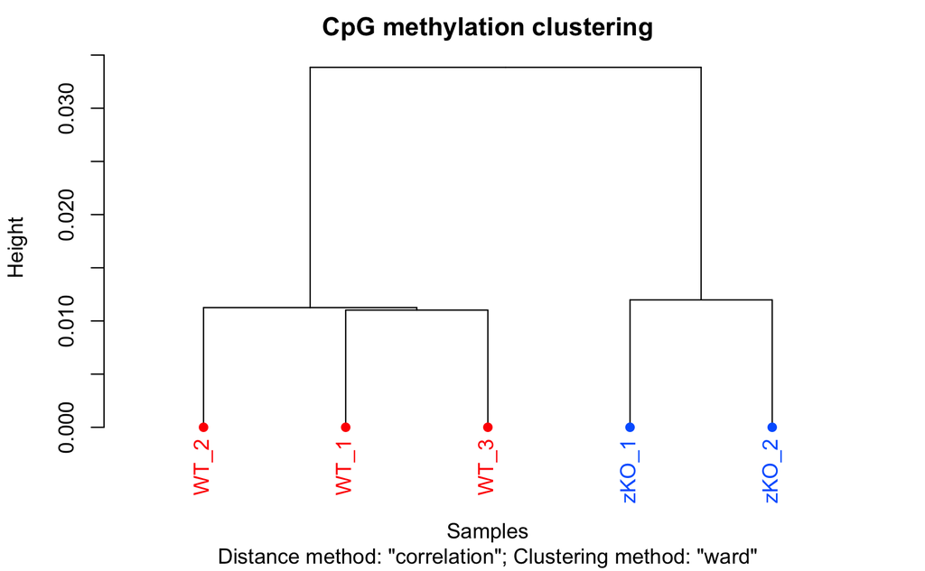

```r
clusterSamples(meth, dist="correlation", method="ward", plot=TRUE)
```

We can also do a PCA analysis on our samples. The following function will plot a scree plot for importance of components.

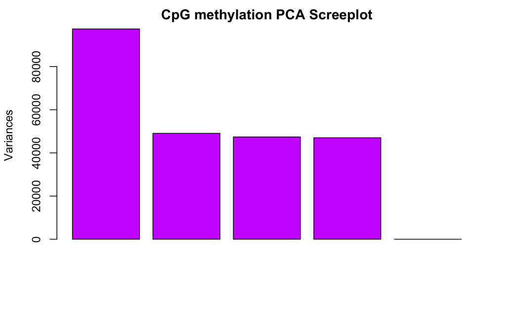

```r
PCASamples(meth, screeplot=TRUE)
```

We can also plot PC1 and PC2 axis and a scatter plot of our samples on those axis which will reveal how they cluster.

```r
pdf("./Plots/pca_analysis.pdf")
  PCASamples(.Object = meth, comp = c(1, 2))
  PCASamples(.Object = meth, comp = c(1, 3))
```

```r
  PCASamples(.Object = meth, comp = c(2, 3))
dev.off()
```

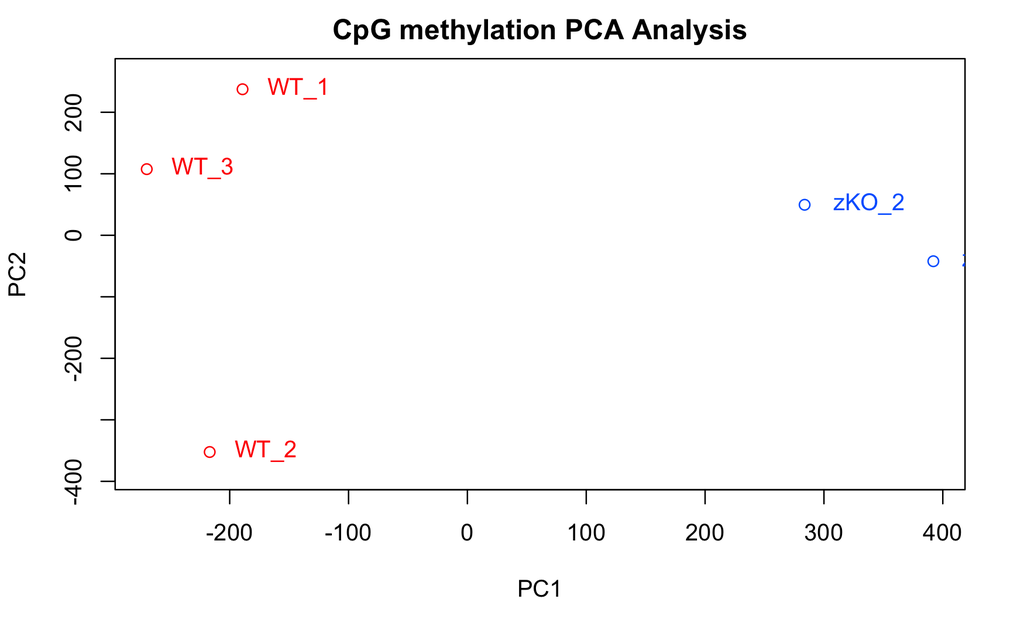

```r
PCASamples(.Object = meth, comp = c(1, 2))
```

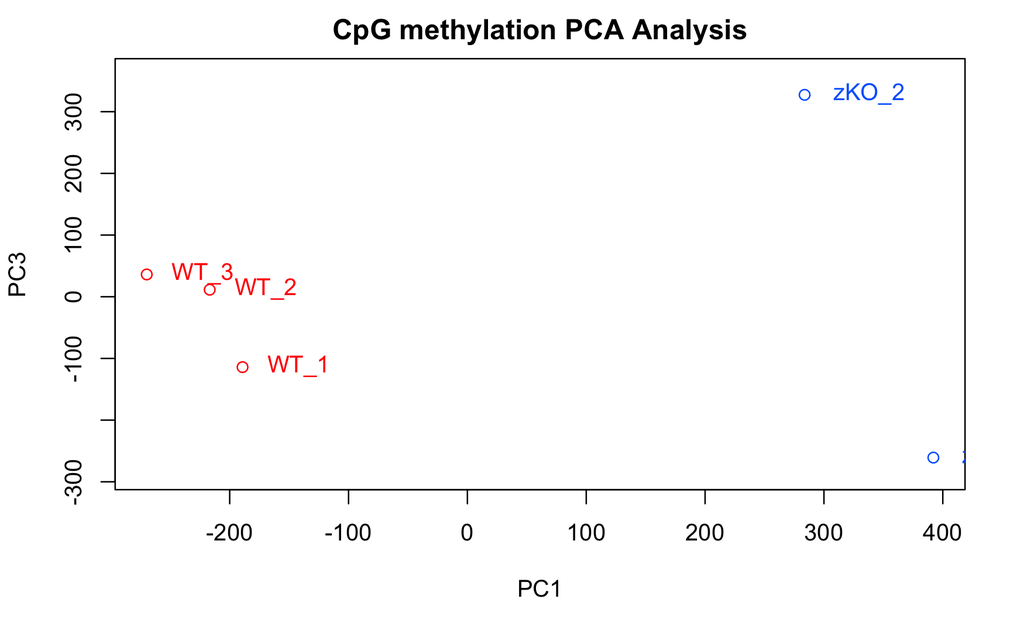

```r
PCASamples(.Object = meth, comp = c(1, 3))
```

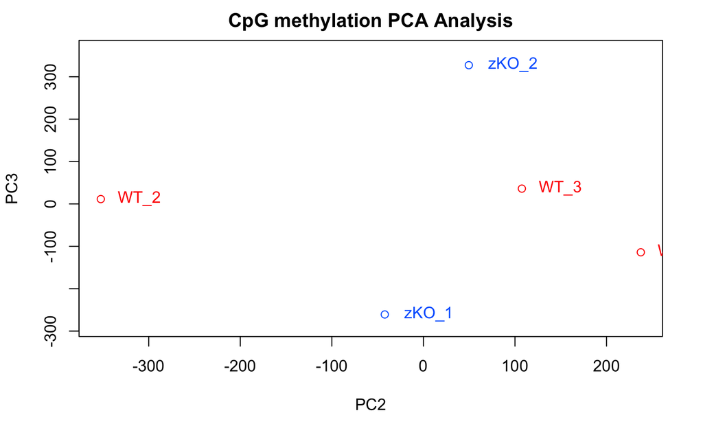

```r
PCASamples(.Object = meth, comp = c(2, 3))
```

```r
myDiff=calculateDiffMeth(meth)
```

```
two groups detected:
 will calculate methylation difference as the difference of
treatment (group: 1) - control (group: 0)
```

```r
myDiff.sign <- myDiff[myDiff$qvalue <= 0.05, ]
```